# document

## About the Author

This report was authored by Ayoub Majjid, a fifth-year computer engineering student at EMSI with a background in Experimental Sciences. His academic journey has provided a strong foundation in mathematics, physics, and chemistry, and has shaped a growing expertise in technology, system design, and data engineering.

Ayoub currently serves as Tech Lead and Entrepreneur at Intellcap, where he leads three innovation projects focused on building impactful and scalable startup solutions. His work emphasizes transforming ideas into robust technical systems, with a particular interest in data platforms, system architecture, and end-to-end engineering workflows.

📧 Email: ayoub@majjid.com 🌐 Website: https://majjid.com

## Copyright & Disclaimer

© 2026 **Ayoub Majjid**. All rights reserved.

This report is provided for **educational and professional demonstration purposes**. The MIMIC-III dataset remains the property of its respective owners and is used in accordance with applicable data usage agreements.

No patient-identifiable information is disclosed or altered in this document.

# 🥈 Silver Layer Analysis

This notebook analyzes the **Silver Layer** of the MIMIC-III Data Warehouse.

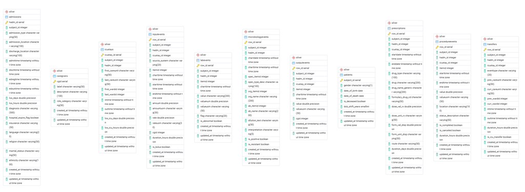

## What is the Silver Layer?

```python
# Setup
import sys
sys.path.insert(0, '../../..')

import pandas as pd
from sqlalchemy import text
from app.shared import get_db

pd.set_option('display.max_columns', None)
pd.set_option('display.width', None)
```

```python
# Helper functions
def query_df(sql, limit=10):
    with get_db() as session:
        result = session.execute(text(sql))
        df = pd.DataFrame(result.fetchall(), columns=result.keys())
    return df.head(limit) if limit else df

def table_count(schema, table):
    with get_db() as session:
        return session.execute(text(f"SELECT COUNT(*) FROM {schema}.{table}")).scalar()
```

## PATIENTS Table (Silver)

[output not shown]

```python
print(f"Total Patients (Silver): {table_count('silver', 'patients'):,}")
query_df("SELECT * FROM silver.patients ORDER BY subject_id LIMIT 5")
```

[output not shown]

|  | subject_id | gender | date_of_birth | date_of_death | is_deceased | dob_shift_years | created_at | updated_at |
| --- | --- | --- | --- | --- | --- | --- | --- | --- |
| 0 | 10006 | F | 2094-03-05 | 2165-08-12 | True | None | 2026-01-01 12:11:42.339197 | 2026-01-01 12:11:42.339197 |
| 1 | 10011 | F | 2090-06-05 | 2126-08-28 | True | None | 2026-01-01 12:11:42.339197 | 2026-01-01 12:11:42.339197 |
| 2 | 10013 | F | 2038-09-03 | 2125-10-07 | True | None | 2026-01-01 12:11:42.339197 | 2026-01-01 12:11:42.339197 |
| 3 | 10017 | F | 2075-09-21 | 2152-09-12 | True | None | 2026-01-01 12:11:42.339197 | 2026-01-01 12:11:42.339197 |
| 4 | 10019 | M | 2114-06-20 | 2163-05-15 | True | None | 2026-01-01 12:11:42.339197 | 2026-01-01 12:11:42.339197 |

```python
# Mortality analysis
query_df("""
    SELECT
        gender,
        COUNT(*) as total,
        SUM(CASE WHEN is_deceased THEN 1 ELSE 0 END) as deceased,
        ROUND(
    (100.0 * SUM(CASE WHEN is_deceased THEN 1 ELSE 0 END) / COUNT(*))::numeric,
    1
) AS mortality_rate
    FROM silver.patients
    GROUP BY gender
""", limit=None)
```

[output not shown]

|  | gender | total | deceased | mortality_rate |
| --- | --- | --- | --- | --- |
| 0 | M | 45 | 45 | 100.0 |
| 1 | F | 55 | 55 | 100.0 |

## ADMISSIONS Table (Silver)

**Transformations from Bronze:**

- Length of stay calculated in days and hours
- Hospital expire flag standardized as boolean
- Date fields normalized

| Column | Type | Description | Transformation |
| --- | --- | --- | --- |
| hadm_id | INTEGER | **PK** - Admission ID | Direct copy |
| subject_id | INTEGER | Patient ID | Direct copy |
| admittime | TIMESTAMP | Admission time | Direct copy |
| dischtime | TIMESTAMP | Discharge time | Direct copy |
| **los_days** | FLOAT | Length of stay (days) | **Calculated**: dischtime - admittime |
| **los_hours** | FLOAT | Length of stay (hours) | **Calculated**: los_days * 24 |
| hospital_expire_flag | BOOLEAN | Died in hospital | **Standardized** to boolean |

```python
print(f"Total Admissions (Silver): {table_count('silver', 'admissions'):,}")
query_df("""
    SELECT hadm_id, subject_id, admission_type, admittime, dischtime,
           los_days, los_hours, hospital_expire_flag
    FROM silver.admissions
    ORDER BY hadm_id LIMIT 5
""")
```

[output not shown]

|  | hadm_id | subject_id | admission_type | admittime | dischtime | los_days | los_hours | hospital_expire_flag |
| --- | --- | --- | --- | --- | --- | --- | --- | --- |
| 0 | 100375 | 10056 | EMERGENCY | 2129-05-02 00:12:00 | 2129-05-06 13:40:00 | 4.56 | 109.47 | False |
| 1 | 100969 | 42430 | EMERGENCY | 2142-11-26 21:20:00 | 2142-11-30 10:55:00 | 3.57 | 85.58 | True |
| 2 | 101361 | 41914 | EMERGENCY | 2145-12-01 18:13:00 | 2145-12-18 17:45:00 | 16.98 | 407.53 | False |
| 3 | 102203 | 42135 | EMERGENCY | 2127-07-23 15:21:00 | 2127-08-04 16:00:00 | 12.03 | 288.65 | False |
| 4 | 103379 | 44228 | EMERGENCY | 2170-12-15 03:14:00 | 2170-12-24 18:00:00 | 9.62 | 230.77 | False |

```python
# LOS statistics by admission type
query_df("""
    SELECT
        admission_type,
        COUNT(*) as admissions,
        ROUND(AVG(los_days::numeric), 2) as avg_los_days,
        ROUND(MIN(los_days::numeric), 2) as min_los_days,
        ROUND(MAX(los_days::numeric), 2) as max_los_days
    FROM silver.admissions
    GROUP BY admission_type
    ORDER BY avg_los_days DESC
""", limit=None)
```

[output not shown]

|  | admission_type | admissions | avg_los_days | min_los_days | max_los_days |
| --- | --- | --- | --- | --- | --- |
| 0 | ELECTIVE | 8 | 11.67 | 4.09 | 39.70 |
| 1 | EMERGENCY | 119 | 9.23 | 0.04 | 123.98 |
| 2 | URGENT | 2 | 6.26 | 5.69 | 6.83 |

## ICUSTAYS Table (Silver)

**Transformations from Bronze:**

- ICU length of stay calculated
- Care unit standardization

| Column | Type | Description | Transformation |
| --- | --- | --- | --- |
| icustay_id | INTEGER | **PK** - ICU stay ID | Direct copy |
| subject_id | INTEGER | Patient ID | Direct copy |
| hadm_id | INTEGER | Admission ID | Direct copy |
| first_careunit | VARCHAR | First ICU unit | Direct copy |
| last_careunit | VARCHAR | Last ICU unit | Direct copy |
| intime | TIMESTAMP | ICU entry time | Direct copy |
| outtime | TIMESTAMP | ICU exit time | Direct copy |
| **los_icu_days** | FLOAT | ICU LOS (days) | **Calculated** |
| **los_icu_hours** | FLOAT | ICU LOS (hours) | **Calculated** |

```python
print(f"Total ICU Stays (Silver): {table_count('silver', 'icustays'):,}")
query_df("""
    SELECT icustay_id, subject_id, hadm_id, first_careunit,
           intime, outtime, los_icu_days, los_icu_hours
    FROM silver.icustays LIMIT 5
""")
```

[output not shown]

|  | icustay_id | subject_id | hadm_id | first_careunit | intime | outtime | los_icu_days | los_icu_hours |
| --- | --- | --- | --- | --- | --- | --- | --- | --- |
| 0 | 258147 | 10042 | 148562 | CSRU | 2147-02-06 12:40:59 | 2147-02-14 16:04:43 | 8.14 | 195.40 |
| 1 | 266122 | 10043 | 168674 | MICU | 2185-04-14 00:23:56 | 2185-04-16 00:44:18 | 2.01 | 48.34 |
| 2 | 270154 | 10044 | 124073 | MICU | 2152-10-03 02:02:49 | 2152-10-07 16:52:38 | 4.62 | 110.83 |
| 3 | 203766 | 10045 | 126949 | MICU | 2129-11-24 22:46:57 | 2129-12-01 06:03:55 | 6.30 | 151.28 |
| 4 | 213289 | 10046 | 133110 | CCU | 2194-07-26 23:49:00 | 2194-07-29 21:01:00 | 2.88 | 69.20 |

```python
# ICU performance metrics
query_df("""
    SELECT
        first_careunit,
        COUNT(*) as total_stays,
        COUNT(DISTINCT subject_id) as unique_patients,
        ROUND(AVG(los_icu_days)::numeric, 2) as avg_icu_los,
        ROUND(MAX(los_icu_days)::numeric, 2) as max_icu_los
    FROM silver.icustays
    GROUP BY first_careunit
    ORDER BY total_stays DESC
""", limit=None)
```

[output not shown]

|  | first_careunit | total_stays | unique_patients | avg_icu_los | max_icu_los |
| --- | --- | --- | --- | --- | --- |
| 0 | MICU | 77 | 56 | 3.96 | 31.12 |
| 1 | SICU | 23 | 20 | 5.67 | 35.41 |
| 2 | CCU | 19 | 18 | 5.75 | 25.00 |
| 3 | TSICU | 11 | 11 | 3.59 | 22.39 |
| 4 | CSRU | 6 | 6 | 3.63 | 8.14 |

## LABEVENTS Table (Silver)

**Transformations from Bronze:**

- Abnormal flag derived from flag column
- Numeric value validation

| Column | Type | Description | Transformation |
| --- | --- | --- | --- |
| row_id | INTEGER | **PK** - Event ID | Direct copy |
| subject_id | INTEGER | Patient ID | Direct copy |
| hadm_id | INTEGER | Admission ID | Direct copy |
| itemid | INTEGER | Lab test ID | Direct copy |
| charttime | TIMESTAMP | Time of test | Direct copy |
| valuenum | FLOAT | Numeric value | Validated |
| valueuom | VARCHAR | Unit of measure | Direct copy |
| **is_abnormal** | BOOLEAN | Abnormal result | **Derived**: flag = ‘abnormal’ |

```python
print(f"Total Lab Events (Silver): {table_count('silver', 'labevents'):,}")
query_df("""
    SELECT row_id, subject_id, itemid, charttime, value, valuenum, valueuom, is_abnormal
    FROM silver.labevents LIMIT 5
""")
```

[output not shown]

|  | row_id | subject_id | itemid | charttime | value | valuenum | valueuom | is_abnormal |
| --- | --- | --- | --- | --- | --- | --- | --- | --- |
| 0 | 6244575 | 10006 | 51137 | 2164-09-24 20:21:00 | 1+ | NaN | None | False |
| 1 | 6244593 | 10006 | 51267 | 2164-09-24 20:21:00 | 2+ | NaN | None | False |
| 2 | 6244594 | 10006 | 51268 | 2164-09-24 20:21:00 | OCCASIONAL | NaN | None | False |
| 3 | 6244595 | 10006 | 51274 | 2164-09-24 20:21:00 | 15.3 | 15.3 | sec | True |
| 4 | 6244596 | 10006 | 51275 | 2164-09-24 20:21:00 | 28.5 | 28.5 | sec | False |

```python
# Abnormal rate analysis
query_df("""
    SELECT
        CASE WHEN is_abnormal THEN 'Abnormal' ELSE 'Normal' END as status,
        COUNT(*) as count,
        ROUND(100.0 * COUNT(*) / SUM(COUNT(*)) OVER(), 1) as percentage
    FROM silver.labevents
    WHERE is_abnormal IS NOT NULL
    GROUP BY is_abnormal
""", limit=None)
```

[output not shown]

|  | status | count | percentage |
| --- | --- | --- | --- |
| 0 | Normal | 46337 | 60.9 |
| 1 | Abnormal | 29737 | 39.1 |

## PRESCRIPTIONS Table (Silver)

**Transformations from Bronze:**

- Duration calculation
- Dose normalization

| Column | Type | Description | Transformation |
| --- | --- | --- | --- |
| row_id | INTEGER | **PK** - Prescription ID | Direct copy |
| subject_id | INTEGER | Patient ID | Direct copy |
| hadm_id | INTEGER | Admission ID | Direct copy |
| drug | VARCHAR | Drug name | Direct copy |
| drug_name_generic | VARCHAR | Generic name | Direct copy |
| startdate | TIMESTAMP | Start time | Direct copy |
| enddate | TIMESTAMP | End time | Direct copy |
| dose_unit_rx | VARCHAR | Dose unit | Direct copy |
| route | VARCHAR | Admin route | Direct copy |

```python
print(f"Total Prescriptions (Silver): {table_count('silver', 'prescriptions'):,}")
query_df("""
    SELECT row_id, subject_id, drug, drug_name_generic, startdate, enddate, route
    FROM silver.prescriptions LIMIT 5
""")
```

[output not shown]

|  | row_id | subject_id | drug | drug_name_generic | startdate | enddate | route |
| --- | --- | --- | --- | --- | --- | --- | --- |
| 0 | 86578 | 43735 | Carvedilol | Carvedilol | 2128-11-05 | 2128-11-05 | PO |
| 1 | 455857 | 10104 | Bisacodyl | Bisacodyl | 2120-08-25 | 2120-08-31 | PO |
| 2 | 456597 | 10104 | NS | None | 2120-08-25 | 2120-08-27 | IV |
| 3 | 653017 | 10027 | Docusate Sodium (Liquid) | Docusate Sodium (Liquid) | 2190-07-13 | 2190-07-16 | NG |
| 4 | 925240 | 41795 | Magnesium Sulfate | None | 2145-09-06 | 2145-09-06 | IV |

```python
# Most common administration routes
query_df("""
    SELECT route, COUNT(*) as count
    FROM silver.prescriptions
    WHERE route IS NOT NULL
    GROUP BY route
    ORDER BY count DESC
    LIMIT 10
""")
```

[output not shown]

|  | route | count |
| --- | --- | --- |
| 0 | IV | 5312 |
| 1 | PO | 2545 |
| 2 | IV DRIP | 828 |
| 3 | SC | 470 |
| 4 | PO/NG | 262 |
| 5 | IH | 238 |
| 6 | PR | 114 |
| 7 | TP | 97 |
| 8 | NG | 94 |
| 9 | IM | 91 |

## Silver Layer Summary

```python
# Silver layer summary
silver_tables = ['patients', 'admissions', 'icustays', 'labevents', 'prescriptions',
                 'transfers', 'inputevents', 'outputevents', 'procedureevents', 'microbiologyevents','caregivers']

summary = []
for table in silver_tables:
    try:
        count = table_count('silver', table)
        summary.append({'table': table, 'count': count})
    except:
        summary.append({'table': table, 'count': 'N/A'})

pd.DataFrame(summary)
```

[output not shown]

|  | table | count |
| --- | --- | --- |
| 0 | patients | 100 |
| 1 | admissions | 129 |
| 2 | icustays | 136 |
| 3 | labevents | 76074 |
| 4 | prescriptions | 10398 |
| 5 | transfers | 524 |
| 6 | inputevents | 48023 |
| 7 | outputevents | 11320 |
| 8 | procedureevents | 753 |
| 9 | microbiologyevents | 2003 |
| 10 | caregivers | 7567 |